# Weather events impact on public health and economy

## Introduction

Storms and other severe weather events can cause both **public health** and **economic** problems for communities and municipalities. Many severe events can result in fatalities, injuries, and property damage, and preventing such outcomes to the extent possible is a key concern. In this report two factors of weather events, *harmfulness* and *costliness*, has been analyzed starting from **U.S. National Oceanic and Atmospheric Administration’s (NOAA)** storm database. This database tracks characteristics of major storms and weather events in the United States, including when and where they occur, as well as estimates of any fatalities, injuries, and property damage.

## Loading packages and storm dataset

The first thing to be done was to import all the needed packages (and download them if not present on the machine). In this case only the ggplot2 and scales packages were fundamentals in order to plot the data in the correct scale

```r
must_have_packages <- c("ggplot2", "scales")
installed_packages <- must_have_packages %in% rownames(installed.packages())
  if (any(installed_packages == FALSE)) {
    install.packages(must_have_packages[!installed_packages])
  }
  invisible(lapply(must_have_packages, library, character.only = TRUE))
```

Then it was time to import the storm dataset and give a look to the documentation in order to better understand the meaning of all the variables

```r
data_url <- "https://d396qusza40orc.cloudfront.net/repdata%2Fdata%2FStormData.csv.bz2"
download.file(data_url, destfile = "storm_data.csv")
storm_data <- read.csv("storm_data.csv")
```

Having a look at the data summary is always a good idea:

```r
hot_columns <- c("EVTYPE", "FATALITIES", "INJURIES", "PROPDMG", "PROPDMGEXP")
summary(storm_data[, hot_columns])
```

```
##     EVTYPE            FATALITIES          INJURIES            PROPDMG
##  Length:902297      Min.   :  0.0000   Min.   :   0.0000   Min.   :   0.00
##  Class :character   1st Qu.:  0.0000   1st Qu.:   0.0000   1st Qu.:   0.00
##  Mode  :character   Median :  0.0000   Median :   0.0000   Median :   0.00
##                     Mean   :  0.0168   Mean   :   0.1557   Mean   :  12.06
##                     3rd Qu.:  0.0000   3rd Qu.:   0.0000   3rd Qu.:   0.50
##                     Max.   :583.0000   Max.   :1700.0000   Max.   :5000.00
##   PROPDMGEXP
##  Length:902297
##  Class :character
##  Mode  :character
##
##
##
```

Just by looking at the data summary, it can be stated that most events cause very few injuries/fatalities and property damages (and some have a huge impact in terms of public health and property damage)

## Across the United States, which types of events are most harmful with respect to population health?

### Data processing

The first step was to extract only the needed columns from the huge raw dataset (storm_data) and aggregate rows (performing separate sums of fatalities and injuries columns) based on the event type (EVTYPE)

```r
hot_cols <- c("EVTYPE", "FATALITIES", "INJURIES")
harm_subset <- storm_data[ , hot_cols]
aggregated_harm_subset <- aggregate(. ~ EVTYPE, harm_subset, sum)
```

Then, in order to compare the “harmfulness” of weather events, a harm score has been calculated. The straight-forward formula is log2(fatalities + injuries) and is needed to better visualize and compare weather events. Unfortunately no stratified data where available on injuries (so the variable is assumed to include *any* kind of injury, from *mild* to *severe*) otherwise a multiplying factor would have been added (like a x2 for fatalities or so)

```r
harm_score <- c(NULL)
for (i in aggregated_harm_subset$EVTYPE) {
  index <- which(aggregated_harm_subset == i)
  fatalities <- aggregated_harm_subset$FATALITIES[index]
  injuries <- aggregated_harm_subset$INJURIES[index]
  harm_score <- append(x = harm_score, values = log2(fatalities + injuries))
}
aggregated_harm_subset$harm_score <- harm_score
```

To make the dataset easier to visualize on plot, since the question to be answered was about *the most harmful event*, a top-5-subset has been created

```r
top_5_dangerous_events <- aggregated_harm_subset[order(-aggregated_harm_subset$harm_score),]
top_5_dangerous_events <- top_5_dangerous_events[1:5,]
```

### Results

After the data tidying, a bar plot has been generated, allowing an intuitive comparison between the most harmful events

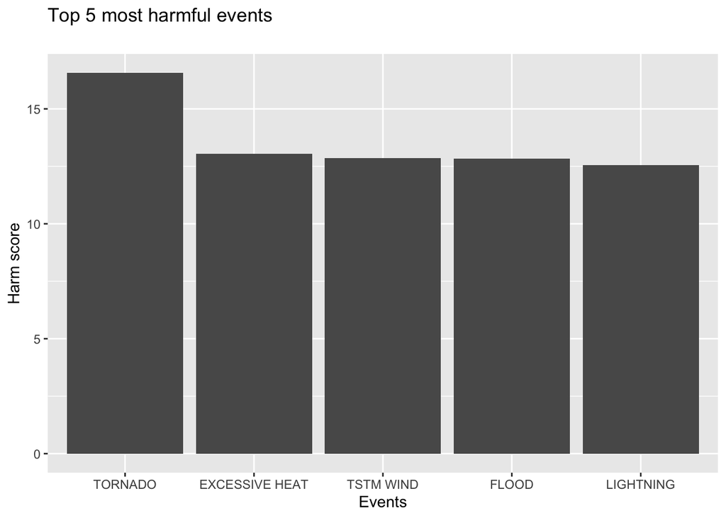

```r
#Plotting the top 5 most harmful events
ggplot(top_5_dangerous_events, aes(x = reorder(EVTYPE, -harm_score), y = harm_score )) +
  geom_col() +
  labs(title = "Top 5 most harmful events\n",
       x = "Events", y = "Harm score", fill = "Events\n") +
  theme(legend.position="none")
```

## Across the United States, which types of events have the greatest economic consequences?

### Data processing

The first step was to **extract only the needed columns** from the huge raw dataset (storm_data) and aggregate rows performing sums of costs (PROPDMG) with the same unit of measure (K, M and B - standing for thousands, millions and billions) based on the event type (EVTYPE). While performing the aggregation, costless events and events with a different unit of measure (different from K, M and B) were removed in order to guarantee that only the *top relevant events* were displayed.

```r
hot_cols_2 <- c("EVTYPE", "PROPDMG", "PROPDMGEXP")
cash_subset <- storm_data[ , hot_cols_2]
aggregated_cash_subset <- aggregate(PROPDMG ~ PROPDMGEXP + EVTYPE, cash_subset, sum)
aggregated_cash_subset <- subset(aggregated_cash_subset,
                                 aggregated_cash_subset$PROPDMG != 0
                                 & aggregated_cash_subset$EVTYPE != "?"
                                 & aggregated_cash_subset$PROPDMGEXP == "K"
                                 | aggregated_cash_subset$PROPDMGEXP == "M"
                                 | aggregated_cash_subset$PROPDMGEXP == "B"
)
```

Then, it was time to **convert the costs using their units of measure**. The issue here was that a column “PROPDMG” with a value -for instance- of *1*, could have had a relative “PROPDMGEXP” of K, M or B, giving a totally different result (1 *thousand*, 1 *million*, 1 *billion*) so a conversion was needed in order to compare the costs of the different events.

```r
converted_cost <- c(NULL)
row.names(aggregated_cash_subset) <- NULL
for(i in 1:length(aggregated_cash_subset$PROPDMGEXP)) {
  if (aggregated_cash_subset$PROPDMGEXP[i] == "K") {factor <- 1000}
  else if (aggregated_cash_subset$PROPDMGEXP[i] == "M") {factor <- 1000000}
  else if (aggregated_cash_subset$PROPDMGEXP[i] == "B") {factor <- 1000000000}
  cost <- aggregated_cash_subset$PROPDMG[i]
  converted_cost <- append(x = converted_cost, values = cost * factor)
  }
aggregated_cash_subset$converted_cost <- converted_cost
```

After the conversion has been done and a *converted_cost* column has been generated, it was time to create a top-5-subset

```r
top_5_expensive_events <- aggregated_cash_subset[order(-aggregated_cash_subset$converted_cost),]
top_5_expensive_events <- top_5_expensive_events[1:5,]
```

### Results

[figure not shown]

```r
ggplot(top_5_expensive_events, aes(x = reorder(EVTYPE, -converted_cost), y = converted_cost )) +
  geom_col() +
    scale_y_continuous(labels = unit_format(unit = "B", scale = 1e-9)) +
  labs(title = "Top 5 most expensive events",
       x = "Events", y = "Economic impact (dollars)", fill = "Events\n") +
  theme(legend.position="none")
```